# Lesson 5

### Multivariate Data

Notes:

- last lesson: 2 quantitative variables
- now: 3 or more variables

### Moira Perceived Audience Size Colored by Age

Notes:

- investigation whether age has an effect in perceived audience size
- added 3rd variable represented with color
- was not very effective

### Third Qualitative Variable

Notes:

- sometimes in exploratory data analysis we reach dead end
- does age have an effect on friend count?
- maybe there is a totally different age distribution for male & female -> draw a boxplot (x = `shape=4`) denotes mean and a line distribution
- also, we create a summary data frame `pf.fc_by_age_gender`

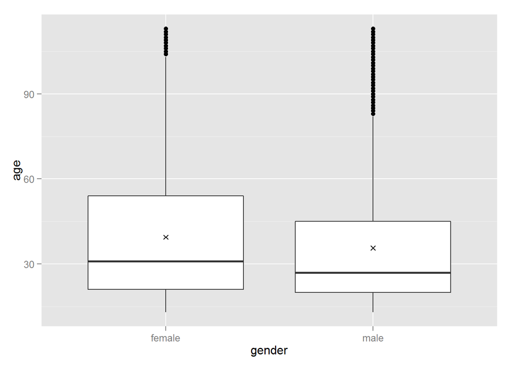

```r
library(ggplot2)
setwd('h:/Dokumente/GitHub/2015_Data_Analyst_Project_4/lesson4/')
pf <- read.csv('pseudo_facebook.tsv', sep='\t')

ggplot(aes(x=gender, y=age),
       data=subset(pf, !is.na(gender))) +
  geom_boxplot() +
  stat_summary(fun.y=mean, geom="point", shape=4)
```

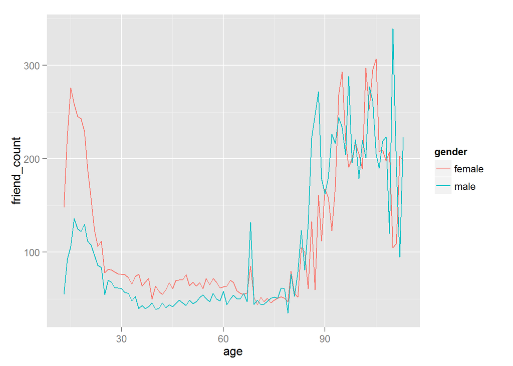

```r
ggplot(aes(x=age, y=friend_count),
       data=subset(pf, !is.na(gender))) +
  geom_line(aes(color=gender), stat="summary", fun.y=median)
```

```r
library(dplyr)
pf.fc_by_age_gender <- pf %>%
  filter(!is.na(gender)) %>%
  group_by(age, gender) %>%
  summarise(mean_friend_count = mean(friend_count),
            median_friend_count = median(friend_count),
            n=n()) %>%
  ungroup() %>%
  arrange(age)
```

### Plotting Conditional Summaries

Notes:

- now we can plot the summary data

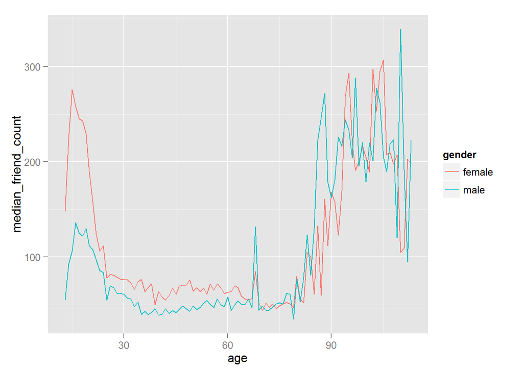

```r
ggplot(aes(x=age, y=median_friend_count),
       data=pf.fc_by_age_gender) +
  geom_line(aes(color=gender), stat="summary", fun.y=median)
```

### Thinking in Ratios

Notes:

- it’s sometimes helpful to understand data in terms of fractions
- e.g., how many times more friends does the average female user have at a certain age?

### Wide and Long Format

Notes:

- **long format**: age, gender, mean_friend_count etc.
- **wide format**: age, male, female etc.

### Reshaping Data

Notes:

```r
#install.packages('reshape2')
library(reshape2)
pf.fc_by_age_gender.wide <- dcast(pf.fc_by_age_gender, age ~ gender, value.var = "median_friend_count")
```

### Ratio Plot

Notes:

- you can specify the ratio `female/male` for `y`
- adding a horizontal line: `geom_hline(...)`

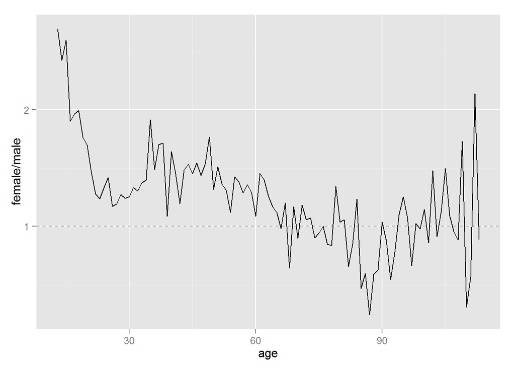

```r
library(ggplot2)
ggplot(aes(x=age, y=female/male), data=pf.fc_by_age_gender.wide) +
  geom_line() +
  geom_hline(yintercept=1, alpha=0.3, linetype=2)
```

### Third Quantitative Variable

Notes:

- how to quantify a difference as ratio when variable is continuous (not categorical)?
- you can make buckets / bins with the `cut` function

```r
pf$year_joined =  floor(2014 - pf$tenure/365)
summary(pf$year_joined)
```

```
##    Min. 1st Qu.  Median    Mean 3rd Qu.    Max.    NA's
##    2005    2012    2012    2012    2013    2014       2
```

```r
table(pf$year_joined)
```

```
##
##  2005  2006  2007  2008  2009  2010  2011  2012  2013  2014
##     9    15   581  1507  4557  5448  9860 33366 43588    70
```

### Cut a Variable

Notes:

- `cut` can make discrete variables from continuous ones

```r
pf$year_joined.bucket <- cut(pf$year_joined, c(2004, 2009, 2011, 2012, 2014))
table(pf$year_joined.bucket, useNA="ifany")
```

```
##
## (2004,2009] (2009,2011] (2011,2012] (2012,2014]        <NA>
##        6669       15308       33366       43658           2
```

### Plotting it All Together

Notes:

- plotting the dependency on variable `year_joined.bucket`works very much like plotting the dependency on `gender`

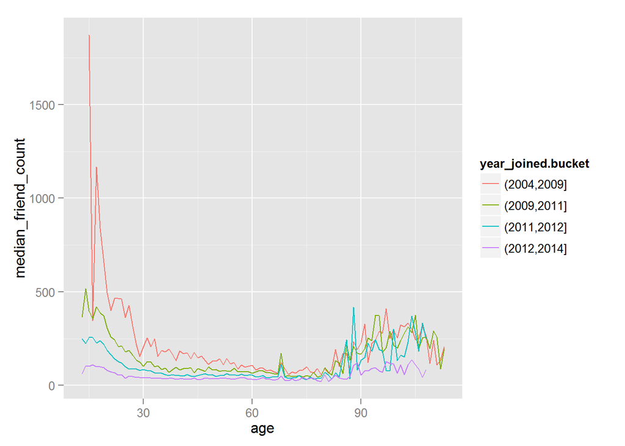

```r
library(dplyr)
pf.fc_by_age_year_joined.bucket <- pf %>%
  filter(!is.na(year_joined.bucket)) %>%
  group_by(age, year_joined.bucket) %>%
  summarise(median_friend_count = median(friend_count),
            mean_friend_count = mean(friend_count),
            n=n()) %>%
  ungroup() %>%
  arrange(age)

ggplot(data=pf.fc_by_age_year_joined.bucket,
       aes(x=age, y=median_friend_count)) +
  geom_line(aes(color=year_joined.bucket))
```

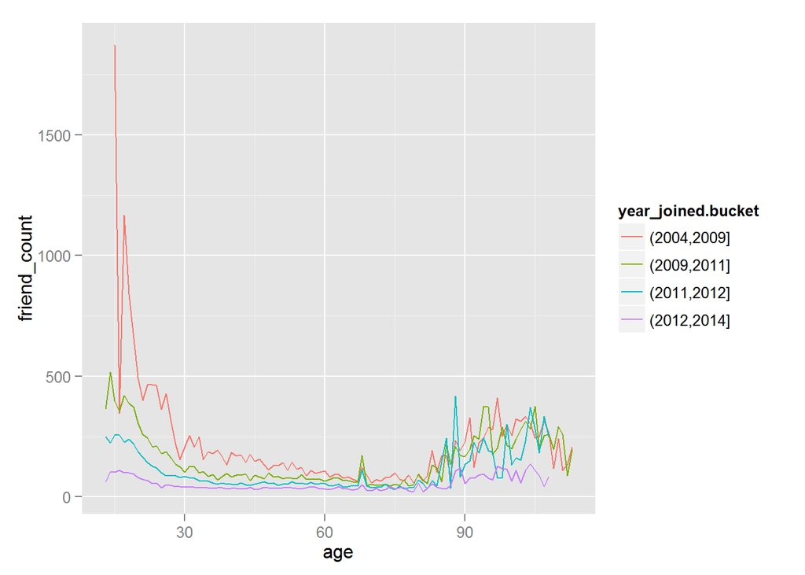

```r
# or:

ggplot(data=subset(pf, !is.na(year_joined.bucket)),
       aes(x=age, y=friend_count)) +
  geom_line(aes(color=year_joined.bucket),
            stat="summary", fun.y=median)
```

### Plot the Grand Mean

Notes:

- Grand Mean can just be plottet by one additional (unspecific col ored) `geom_line(...)`
- we can see, that much of the data is about recently joined cohorts

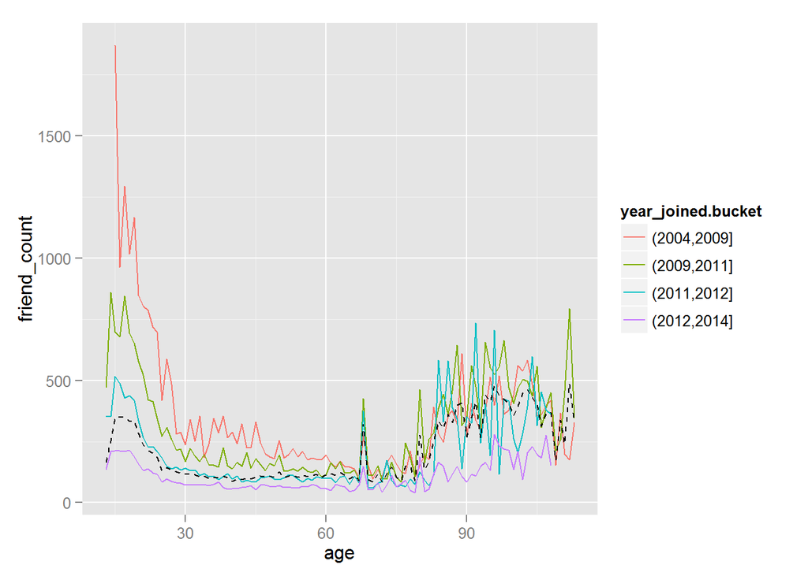

```r
ggplot(data=subset(pf, !is.na(year_joined.bucket)),
       aes(x=age, y=friend_count)) +
  geom_line(aes(color=year_joined.bucket),
            stat="summary", fun.y=mean) +
  geom_line(stat="summary", fun.y=mean,
            linetype=2)
```

### Friending Rate

Notes:

```r
with(subset(pf, tenure >= 1), summary(friend_count/tenure))
```

```
##     Min.  1st Qu.   Median     Mean  3rd Qu.     Max.
##   0.0000   0.0775   0.2205   0.6096   0.5658 417.0000
```

**What is the median friend rate?** 0.2205

**What is the maximum friend rate?** 417.0000

### Friendships Initiated

Notes:

- do users who are longer on the site initiate more friendships?
- plot friendships initiated vs. tenure

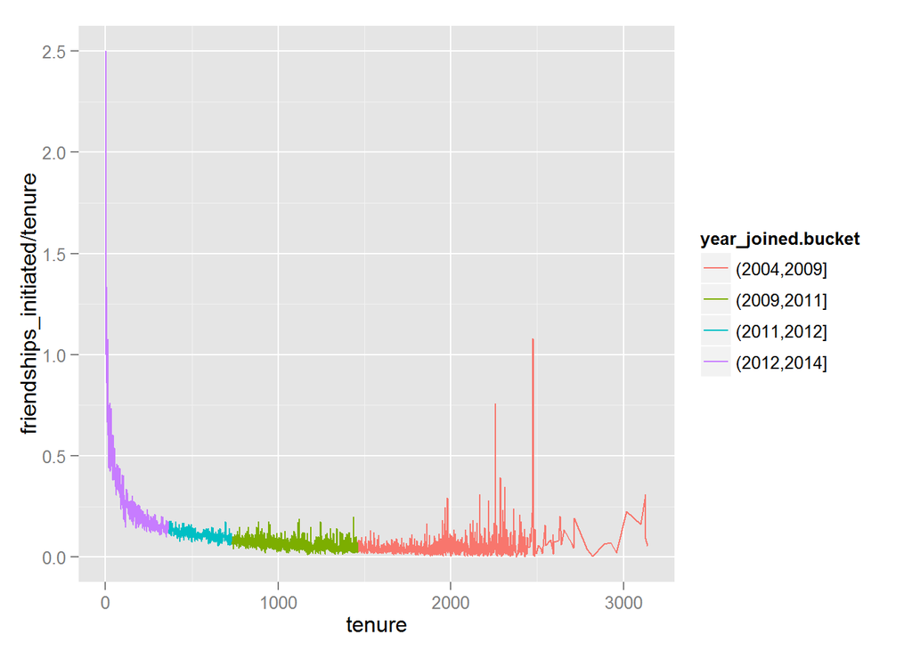

```r
ggplot(data=subset(pf, !is.na(year_joined.bucket) & tenure >= 1),
       aes(x=tenure, y=friendships_initiated/tenure)) +
  geom_line(aes(color=year_joined.bucket),
            stat="summary", fun.y=median)
```

- people with more tenure generally initiate less friendships

### Bias-Variance Tradeoff Revisited

Notes:

- smoothing out plot with `aes(x=n*round(var/n), ...)` increases bin size
- higher bin size -> higher bias -> lower variance / noise
- same effect `geom_smooth(...)`

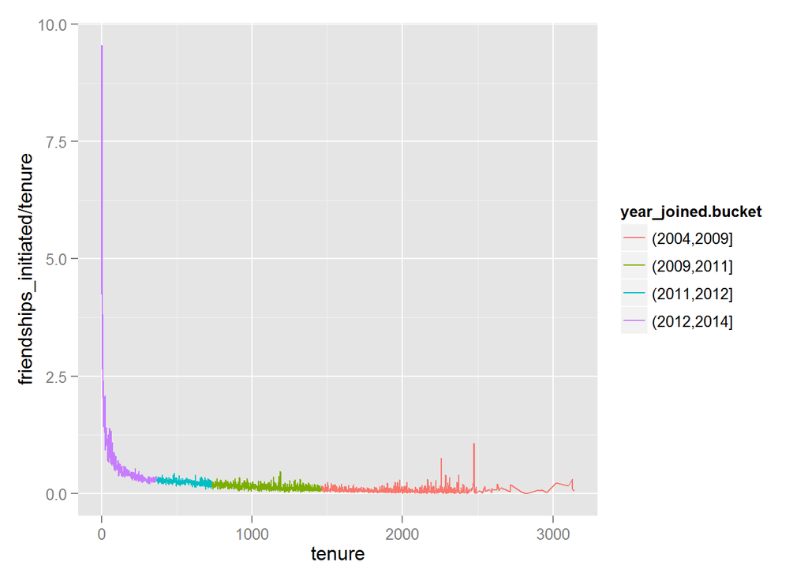

```r
ggplot(aes(x = tenure, y = friendships_initiated / tenure),
       data = subset(pf, tenure >= 1)) +
  geom_line(aes(color = year_joined.bucket),
            stat = 'summary',
            fun.y = mean)
```

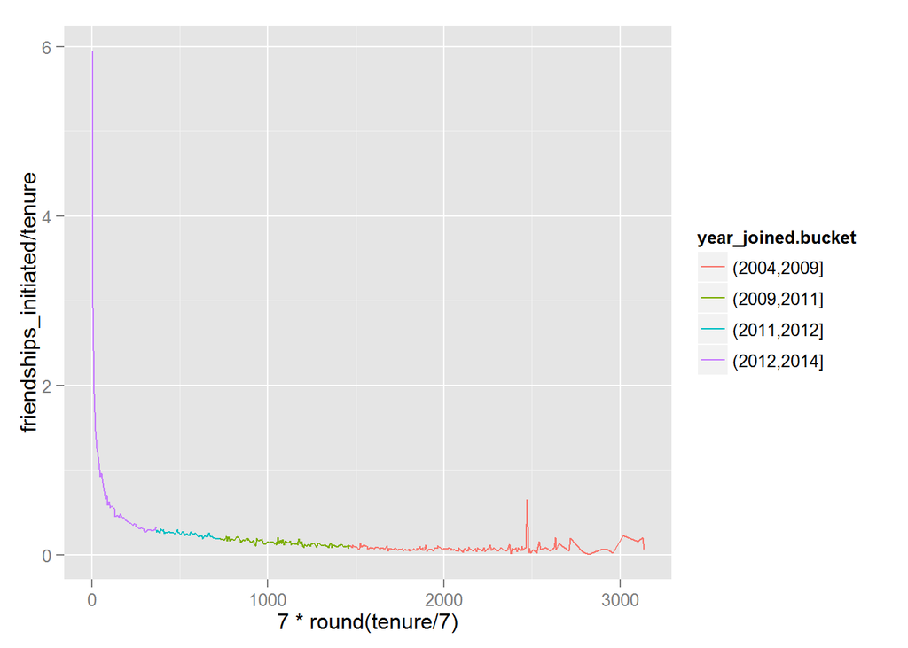

```r
ggplot(aes(x = 7 * round(tenure / 7), y = friendships_initiated / tenure),
       data = subset(pf, tenure > 0)) +
  geom_line(aes(color = year_joined.bucket),
            stat = "summary",
            fun.y = mean)
```

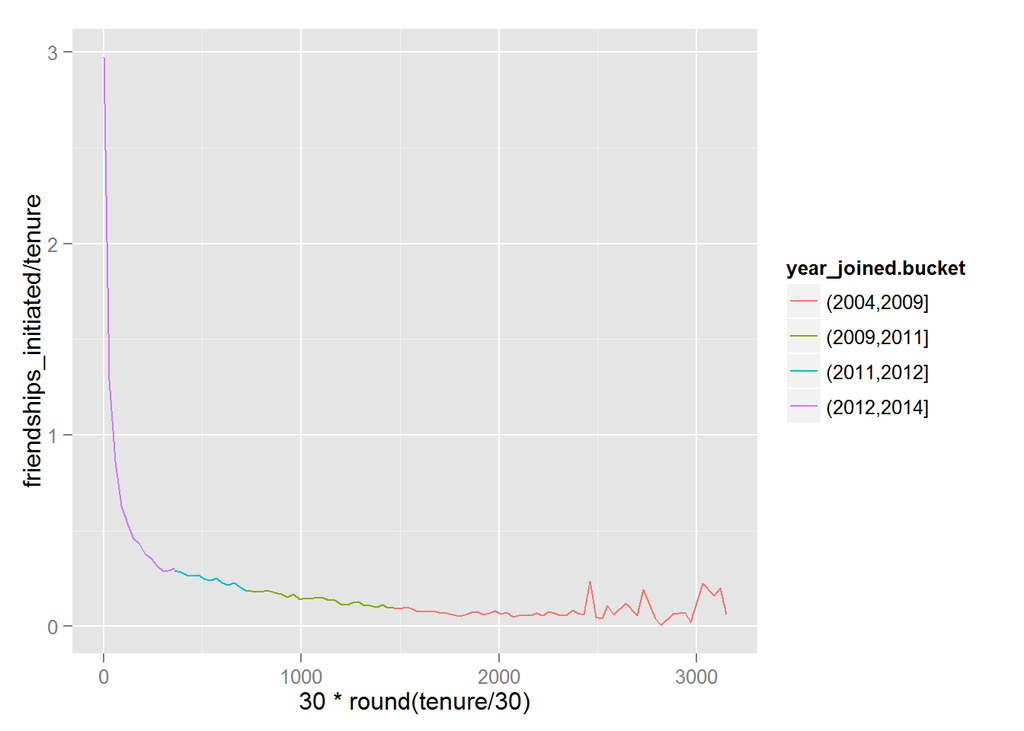

```r
ggplot(aes(x = 30 * round(tenure / 30), y = friendships_initiated / tenure),
       data = subset(pf, tenure > 0)) +
  geom_line(aes(color = year_joined.bucket),
            stat = "summary",
            fun.y = mean)
```

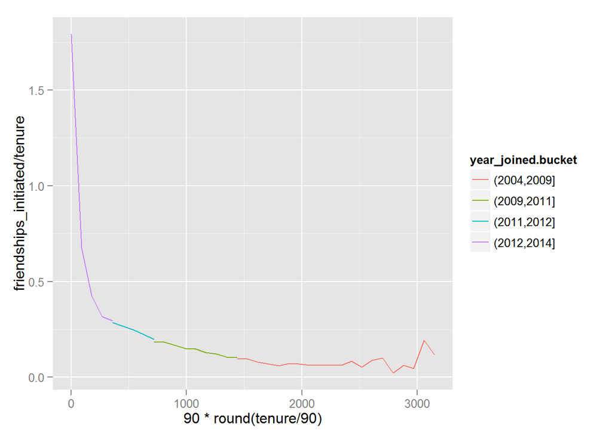

```r
ggplot(aes(x = 90 * round(tenure / 90), y = friendships_initiated / tenure),
       data = subset(pf, tenure > 0)) +
  geom_line(aes(color = year_joined.bucket),
            stat = "summary",
            fun.y = mean)
```

```
## geom_smooth: method="auto" and size of largest group is >=1000, so using gam with formula: y ~ s(x, bs = "cs"). Use 'method = x' to change the smoothing method.
```

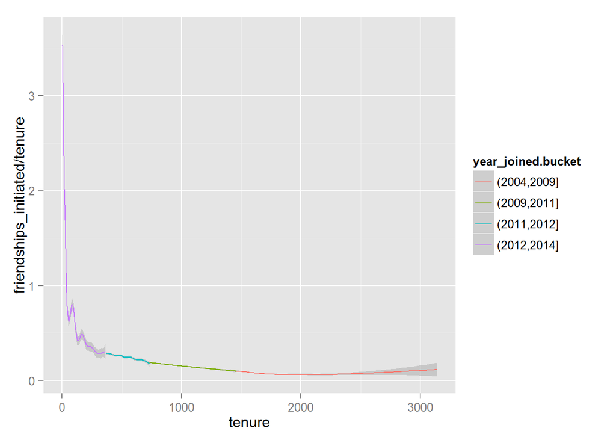

```r
# Smoother (geom_smoot(...)):

ggplot(aes(x = tenure, y = friendships_initiated / tenure),
       data = subset(pf, tenure >= 1)) +
  geom_smooth(aes(color = year_joined.bucket))
```

### Sean’s NFL Fan Sentiment Study

Notes:

- how to visualize fan sentiment on sports groups
- ratio of positive to negative words in 5 minute increments over a season of 4 months
- how to get less noisy data?
- compute moving average (good interval: 1 day) -> still too noisy
- use a “spline” -> more predictable but too smooth -> doesn’t capture jumps in sentiment on game days
- 7 day average always includes last game -> best depiction of the data
- generally, a bigger window for moving averages increases bias, decreases variance
- combined with spline based model -> best of both worlds (including “jumps” on game day)

### Introducing the Yogurt Data Set

Notes:

- data from Danone Yogurt purchases over time by household
- identifier of household is credit card
- representative of typical data mined in retail industry
- structure of Yogurt data is quite different: many rows per household, each row for one purchase occasion
- different kinds of questions may be answered about individual household

### Histograms Revisited

Notes:

```r
setwd('h:/Dokumente/GitHub/2015_Data_Analyst_Project_4/lesson5/')
yo <- read.csv('yogurt.csv')
yo$id <- factor(yo$id)
str(yo)
```

```
## 'data.frame':    2380 obs. of  9 variables:
##  $ obs        : int  1 2 3 4 5 6 7 8 9 10 ...
##  $ id         : Factor w/ 332 levels "2100081","2100370",..: 1 1 1 1 1 1 1 1 1 1 ...
##  $ time       : int  9678 9697 9825 9999 10015 10029 10036 10042 10083 10091 ...
##  $ strawberry : int  0 0 0 0 1 1 0 0 0 0 ...
##  $ blueberry  : int  0 0 0 0 0 0 0 0 0 0 ...
##  $ pina.colada: int  0 0 0 0 1 2 0 0 0 0 ...
##  $ plain      : int  0 0 0 0 0 0 0 0 0 0 ...
##  $ mixed.berry: int  1 1 1 1 1 1 1 1 1 1 ...
##  $ price      : num  59 59 65 65 49 ...
```

```
## stat_bin: binwidth defaulted to range/30. Use 'binwidth = x' to adjust this.
```

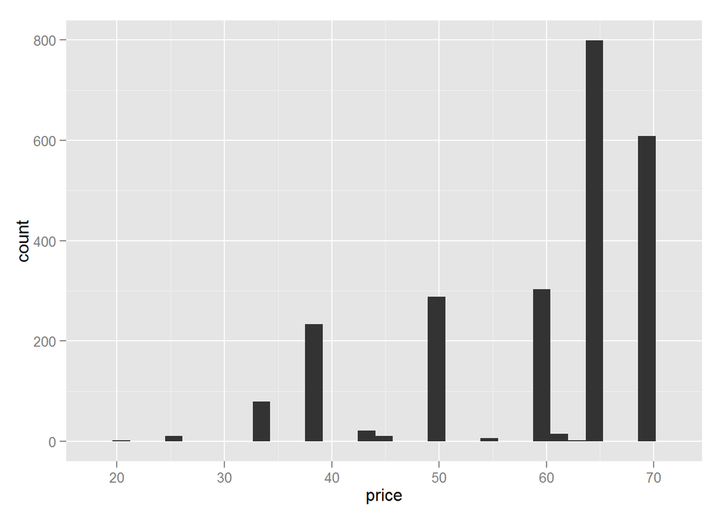

```r
qplot(data=yo, x=price)
```

**What do you notice?**: Increasing price; discreetness (some gaps in between) - can be missed with other binwidth

- `summary(...)` does not easily show us the discreetness of the prices
- however, `length(unique(...))` can show us, that for a large with of the distribution there are only about 20 different unique values
- `table(...)` also works very well (like histograms)

```r
summary(yo$price)
```

```
##    Min. 1st Qu.  Median    Mean 3rd Qu.    Max.
##   20.00   50.00   65.04   59.25   68.96   68.96
```

```r
length(unique(yo$price))
```

```
## [1] 20
```

```r
table(yo$price)
```

```
##
##    20 24.96 33.04  33.2 33.28 33.36 33.52 39.04    44 45.04 48.96 49.52
##     2    11    54     1     1    22     1   234    21    11    81     1
##  49.6    50 55.04 58.96    62 63.04 65.04 68.96
##     1   205     6   303    15     2   799   609
```

### Number of Purchases

Notes:

- on a given purchasing occasion, how many Danone yogurts does a household purchase?
- `transform(...)` makes it possible to add another variable with the sum of a few variables

```r
yo <- transform(yo, all.purchases = strawberry + blueberry + pina.colada + plain + mixed.berry)
summary(yo$all.purchases)
```

```
##    Min. 1st Qu.  Median    Mean 3rd Qu.    Max.
##   1.000   1.000   2.000   1.971   2.000  21.000
```

```
## stat_bin: binwidth defaulted to range/30. Use 'binwidth = x' to adjust this.
```

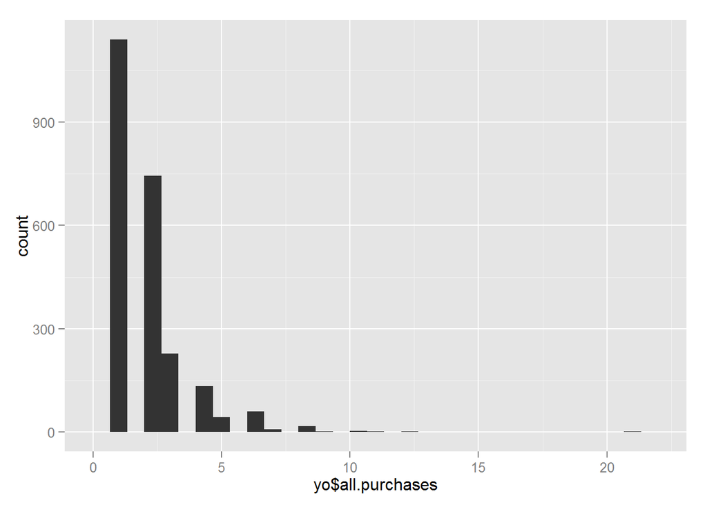

```r
qplot(yo$all.purchases)
```

We can notice, that most households buy more than one yogurt at a time.

### Prices over Time

Notes:

- scatterplot of price vs. time

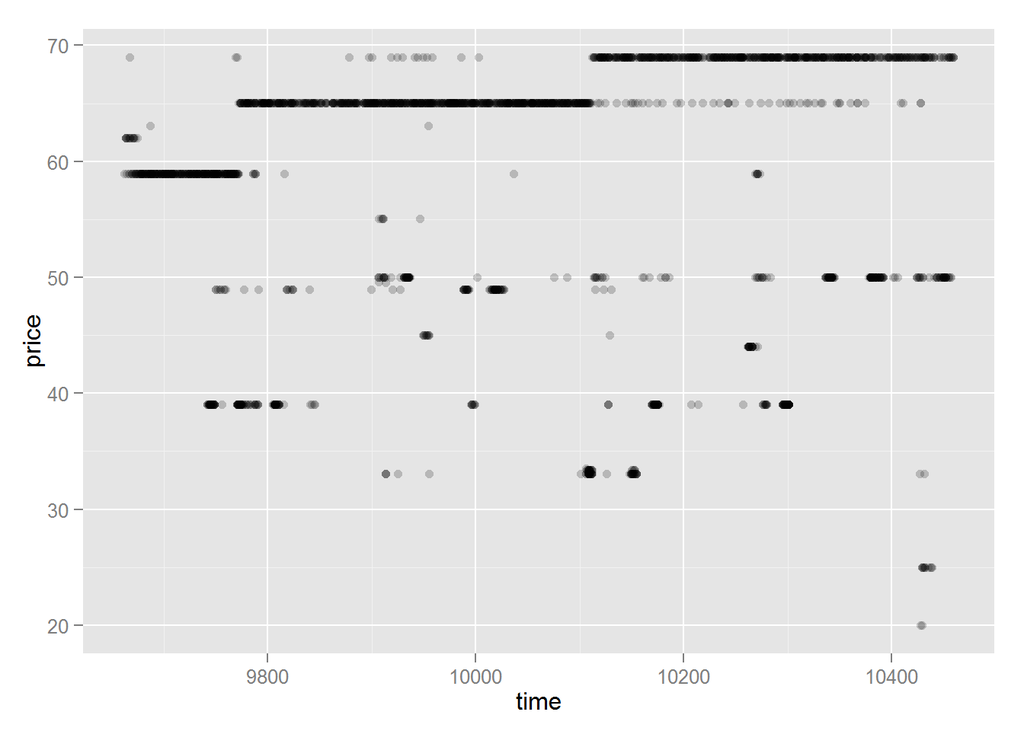

```r
ggplot(data=yo, aes(x=time, y=price)) +
  geom_point(alpha=0.2)
```

**What do you notice?:**

- overall increase in the price
- some lower price values (coupons?)

### Sampling Observations

Notes:

- when familiarizing with a new dataset that contains multiple observations of the same units, it might be useful to work with samples of the data set (easier to display)
- yogurt dataset: maybe choose a small number of households in order to assess variability within / between households etc.
- e.g., originally, the yogurt dataset was used to model consumer preference for variety
- questions to be answered: how often do households buy yogurt? how often do they buy multiple items? what prices do they buy yogurt at?
- let’s pick 16 households

### Looking at Samples of Households

Notes:

- `set.seed(4230)` makes the sampling reproducible
- `sample(levels(factor), n)` samples `n` single samples from a factor
- faceting over `id` (“case variable”)

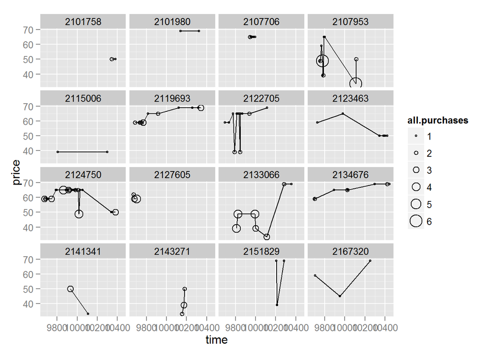

```r
set.seed(4230)
sample.ids <- sample(levels(yo$id), 16)

# drawing a little diagram for every household with the number of purchases indicated by the symbol
ggplot(aes(x=time, y=price),
       data=subset(yo, id %in% sample.ids)) +
  facet_wrap(~id) +
  geom_line() +
  geom_point(aes(size=all.purchases), pch=1)
```

We could also join in the coupon data to explain lower prices.

### The Limits of Cross Sectional Data

Notes:

- cross sectional data (like our facebook data) cannot be faceted by case (only one single row per case)
- if we had better data about cases (users) over time, this could explain better the relation in friendships_initiated dropping over tenure

### Many Variables

Notes:

- until now: variable was always pre-chosen
- trying to confirm that relationship between two variables is consistent across third, fourth etc. variable
- but how to identify auxiliary variables? (maybe even 10, 20 or hundreds of others? or summarizing them into a computed subset of relevant variables?)
- there are some tools to create many plots at once

### Scatterplot Matrix

Notes:

- grid of scatterplot between every pair of variables with `ggpairs(...)` from `GGally` library

```r
#install.packages("GGally")
library(GGally)
#theme_set(theme_minimal(20))
set.seed(1836)
pf_subset <- pf[, c(2:15)]
names(pf_subset)
```

```
##  [1] "age"                   "dob_day"
##  [3] "dob_year"              "dob_month"
##  [5] "gender"                "tenure"
##  [7] "friend_count"          "friendships_initiated"
##  [9] "likes"                 "likes_received"
## [11] "mobile_likes"          "mobile_likes_received"
## [13] "www_likes"             "www_likes_received"
```

```r
ggpairs(pf_subset[sample.int(nrow(pf_subset), 1000), ])
```

[output not shown]

[figure not shown]

**Correlation between `friendships_initiated` and `friendcount`:** 0.769

**Correlation between `age` and `mobile_likes`:** -0.0475

- the diagonal shows the distribution of every variable
- the plots below the diagonal show plots with x and y maped to either of the variables
- for the variables including “gender” (categorical variable) faceted histograms (for discrete data) or boxplots (for continuous data) are shown
- for some variables, we might want to switch to another scale (like logarithmic) - not possible with `ggpairs`

### Even More Variables

Notes:

- another example: genomic data - extremely many variables (measurements) - over thousands - for even small samples!
- use case: genes that are related to a certain disease
- dataset with expression of 6830 genes related to a tumor with a reference baseline

### Heat Maps

Notes:

- here is some data with 64 variables
- first: create a long format (with 64 variables spread out into single rows) using `melt`
- then: re-naming values and and plotting over-expressed and under-expressed genes by case
- here we only look at 200 genes

```r
nci <- read.table("nci.tsv")
colnames(nci) <- c(1:64)
```

```r
nci.long.samp <- melt(as.matrix(nci[1:200,]))
names(nci.long.samp) <- c("gene", "case", "value")
head(nci.long.samp)
```

```
##   gene case  value
## 1    1    1  0.300
## 2    2    1  1.180
## 3    3    1  0.550
## 4    4    1  1.140
## 5    5    1 -0.265
## 6    6    1 -0.070
```

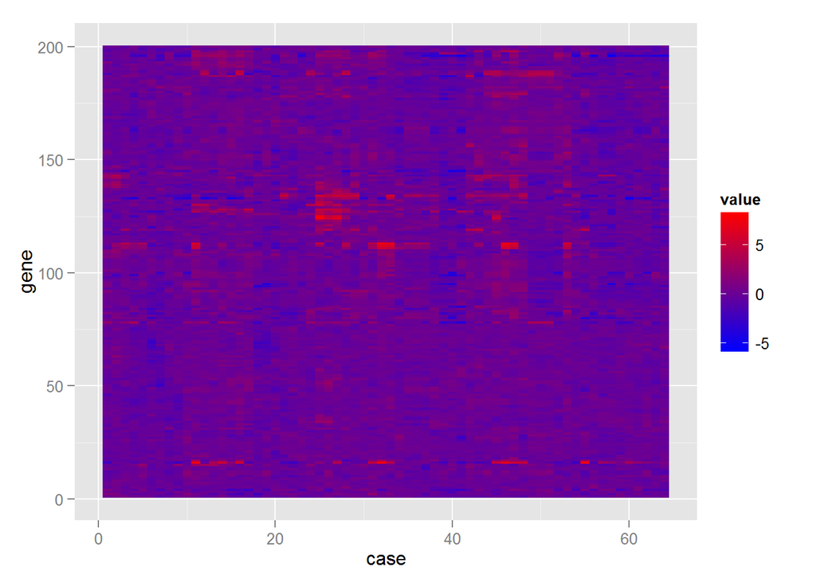

```r
ggplot(aes(y = gene, x = case, fill = value),
  data = nci.long.samp) +
  geom_tile() +
  scale_fill_gradientn(colours = colorRampPalette(c("blue", "red"))(100))
```

### Analyzing Three of More Variables

Reflection:

- inferring one variable from others
- reshaping data between long and wide formats
- using smoothers or adding summaries
- using color as another visual cue to display variables
- data with many observation per sample value and with only one observation (over time)
- subsampling data
- creating scatterplot matrices
- creating heatmaps

Click **KnitHTML** to see all of your hard work and to have an html page of this lesson, your answers, and your notes!